# Dominance is necessary to explain human status hierarchies

Extended Online Version and Supplemental

Joey T. Cheng, Jessica L. Tracy, & Joseph Henrich

2020-12-03

# Introduction

Durkee et al. (2020) (hereafter, DLB) conducted a cross-cultural investigation of people’s beliefs about how traits, behaviors, and practices that enhance an individual’s perceived ability to generate benefits (prestige) or inflict costs (dominance) promote perceived social status in humans. Below, in Section S1, we identify multicollinearity in DLB’s statistical analyses and explain how this statistical problem renders their results inconclusive as to how benefit-delivery and cost-infliction contribute to status allocation. In Section S2, we outine flaws in DLB’s operationalization and measures of social status, and discuss how they bias results toward benefit-delivery and underestimate any effect of cost-infliction. Finally, in Section S3, we discuss a broader problem with the critical assumption underlying DLB’S approach: people’s subjective beliefs about what determines status do not serve as sufficient evidence for determining how status asymmetries are *actually* established in real life. Together, these three major issues severely undermine DLB’s conclusion that there is little evidence for dominance. In closing, we briefly survey the broader empirical record on actual status relations among real people (rather than people’s beliefs about what leads to status), conducted both in the lab and in naturalistic settings; these studies consistently yield opposite conclusions to DLB and demonstrate that both prestige and dominance govern human status hierarchies.

DLB’s original data and code are available here: https://osf.io/57yu8/. Code and data for reproducing the analyses in this reply can be found at: https://github.com/joeytcheng/Dominance-Necessary-to-Explain-Status.

# S1. Collinearity limits inferences about the importance of dominance

In this section, we discuss the problem of collinearity in DLB’s analyses and the implications of this limitation on the authors’ results. We then report results from a more appropriate alternative analysis of DLB’s data that partially addresses collinearity, and show that even minor re-specifications addressing this issue produce the opposite conclusion to that proposed by DLB.

## S1.1 The problem of collinearity

In their critical main test, DLB regressed `status-impact ratings` on four simultaneous predictors that capture the extent to which a given trait or behavior is inferred to signal the displayer’s (a) `benefit-generation ability (BGA)`, (b) `benefit-generation willingness (BGW)`, (c) `cost-infliction ability (CIA)`, and (d) `cost-infliction willingness (CIW)`. This approach aimed to isolate the unique contribution of each of these four predictors, and therefore should, in principle, address whether status differences arise from benefit conferral (prestige) or cost infliction (dominance) or both. However, DLB overlooked the problem of multicollinearity that plagues the suite of predictors. To see the extent of this issue, consider the strong positive associations among all four predictors:

Figure 1 | A pairs plot showing pairwise associations between the four predictors in DLB data. Benefit-generation ability (BGA) and willingness (BGW), and cost-infliction ability (CIA) and willingness (CIW), are each strongly positively correlated both within and across benefit and cost domains. In particular, within domain predictors–BGA and BGW, and CIA and CIW–are so strongly correlated that they are, for practical purposes, redundant. Across domains (such as BGA with CIA), collinearity is especially high among female targets.

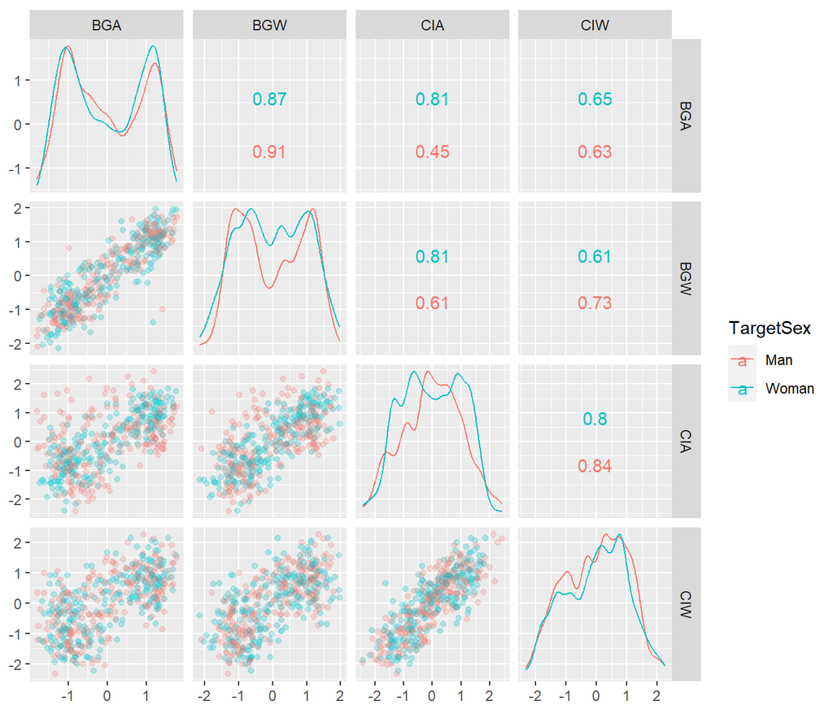

Furthermore, two commonly used indices indicate serious collinearity problems. First, the exceptionally strong positive associations among predictors—particularly between ability and willingness (BGA & BGW, *r*s = 0.87 - 0.91; CIA & CIW, *r*s = 0.80 - 0.84)—exceed the conventional cut-offs for diagnosing collinearity (*r* < 0.80; Berry et al., 1985). Second, the variance inflation factor (VIF) on all four predictors exceed the 2.5 threshold that warrants collinearity concern (Johnston et al., 2018; Vatcheva et al., 2016):

```r
fit.4.predictors <- lm(Status ~
                         BGA + BGW + CIA + CIW,
                       data = agg_df)

library(car)
vif(fit.4.predictors)
```

```
##      BGA      BGW      CIA      CIW
## 4.854797 5.763175 3.680333 3.345738
```

The profound impact of ignoring collinearity on statistical inference is widely recognized and well documented (Cohen et al., 2013; Kutner et al., 2005). Multicollinearity creates a range of interpretational challenges but the crux of the problem, as applied to DLB’s paper, is that the collinearity among predictors obscures the identification of important predictors. With such exceptionally strong associations between BGA and BGW (*r* > 0.87) and between CIA and CIW (*r* > 0.80), these predictors contain almost perfectly redundant information. Regression models reveal how much each predictor adds to the *unique* prediction of the outcome. As such, while any one of these predictors may be in truth an important predictor of `Status`, the effect of each may not be shown to matter in the regression model *once the effect of any one predictor is already known*. Regardless of their true contribution to `Status`, the collinearity among predictors guarantees that each will be shown to be unimportant in the model estimates (Kutner et al., 2005). This means that any conclusions from DLB’S models are misleading because the data, as modeled, are ill suited for investigating how benefit-delivery and cost-infliction each contribute to status.

## S1.2 Simulating collinearity

To illustrate how collinearity undermines DLB’s conclusions, here we conduct a series of simulations. We simulate five datasets with increasingly large correlations among four predictors: `BGA`, `BGW`, `CIA`, and `CIW`. Across all scenarios, the true association of `Status` (the outcome) with `BGA` and `BGW` are each fixed at *r* = 0.50, while the associations with `CIA` and `CIW` are fixed at *r* = 0.40. These chosen associations represent moderate to large effect sizes. In each, we simulate data for 240 behavioral items or events, as in DLB. Across these 5 cases, we begin with data absent of any collinearity (Case 1), and progressively increase the correlation among predictors to ultimately approximate the severe collinearity observed in DLB’s data (Case 5)

In Case 1, we first consider a situation free of any collinearity. The correlation among all four predictors is zero:

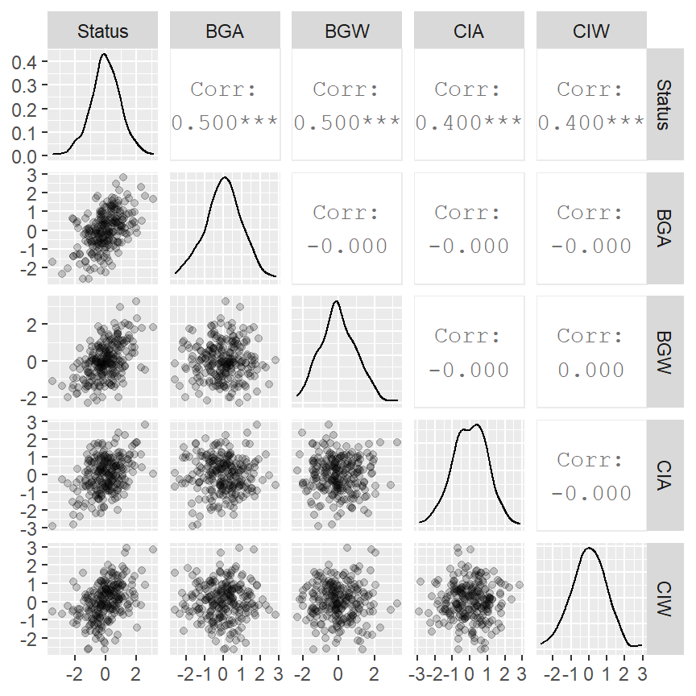

Case 1. No collinearity

```r
conflict_prefer("wrap", "GGally")

set.seed(48096325)

library(faux)
cmatCase1 <-
  c(1, .5, .5, .4, .4,  # corrs between DV & 4 predictors
    .5, 1, 0, 0, 0,
    .5, 0, 1, 0, 0,
    .4, 0, 0, 1, 0,
    .4, 0, 0, 0, 1)
Case1.df <- # sim 240 samples, 5 vars, M = 0, SD = 1
  rnorm_multi(
    240,
    5,
    0,
    1,

    cmatCase1,
    varnames = c( # variable names
      "Status",
      "BGA",
      "BGW",
      "CIA",
      "CIW"),
    empirical = TRUE
  )

library(GGally)
ggpairs(Case1.df, # get scatterplot matrix
        lower = list(continuous = wrap(ggally_points,
                                       alpha = .2)))
```

In Case 2, we move to a low collinearity situation with weak correlations among predictors. Ability and willingness variables *within* benefits or costs domains, *r* = 0.20. *Across* domains, benefits and costs predictors *r* = 0.10.

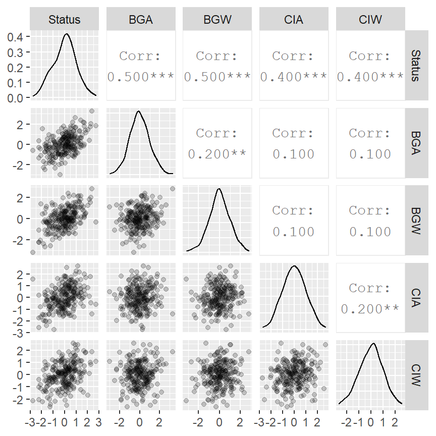

Case 2. Low collinearity

```r
cmatCase2 <- c(1, .5, .5, .4, .4,
                 .5, 1, .2, .1, .1,
                 .5, .2, 1, .1, .1,
                 .4, .1, .1, 1, .2,
                 .4, .1, .1, .2, 1)
Case2.df <- rnorm_multi(240, 5, 0, 1,
  cmatCase2,
  varnames = c("Status", "BGA", "BGW", "CIA", "CIW"),
  empirical = TRUE)

ggpairs(Case2.df,
        lower = list(continuous = wrap(ggally_points,
                                       alpha = .2)))
```

Case 3 exhibits moderate collinearity, with moderate correlations among predictors. *Within* domains, ability and willingness predictors *r* = 0.60. *Across* domains, benefits and costs predictors *r* = 0.50.

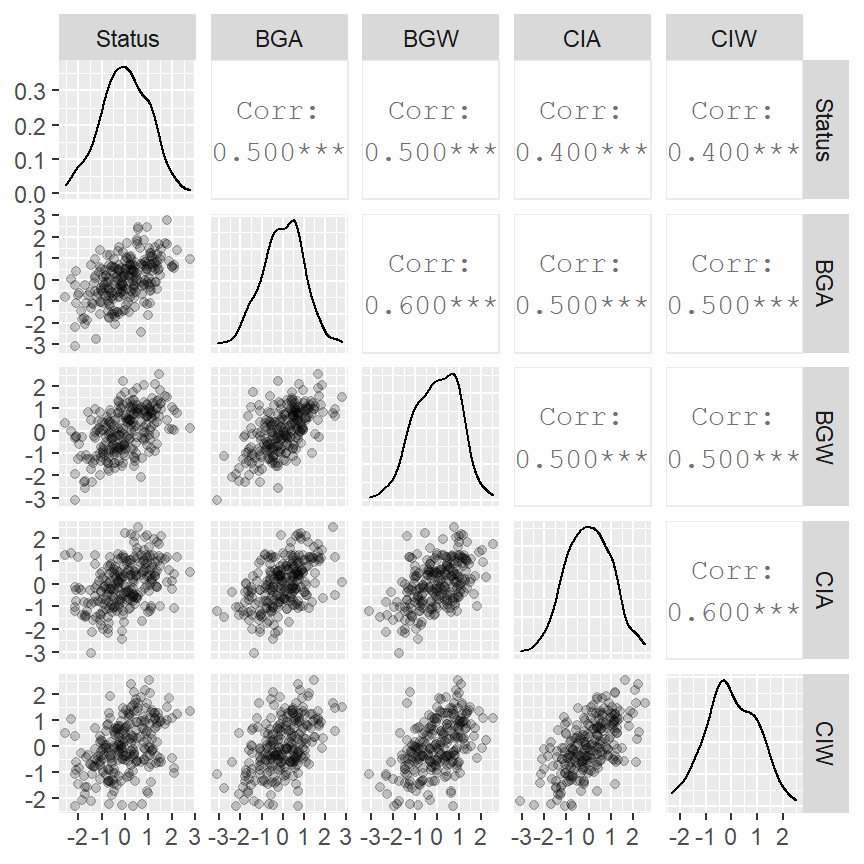

Case 3. Moderate collinearity

```r
cmatCase3 <- c(1, .5, .5, .4, .4,
                 .5, 1, .6, .5, .5,
                 .5, .6, 1, .5, .5,
                 .4, .5, .5, 1, .6,
                 .4, .5, .5, .6, 1)
Case3.df <- rnorm_multi(240, 5, 0, 1,
  cmatCase3,
  varnames = c("Status", "BGA", "BGW", "CIA", "CIW"),
  empirical = TRUE)

ggpairs(Case3.df,
        lower = list(continuous = wrap(ggally_points,
                                       alpha = .2)))
```

Case 4 presents high collinearity created by strong correlations among predictors. *Within* domains, ability and willingness predictors *r* = 0.80. *Across* domains, benefits and costs predictors *r* = 0.70.

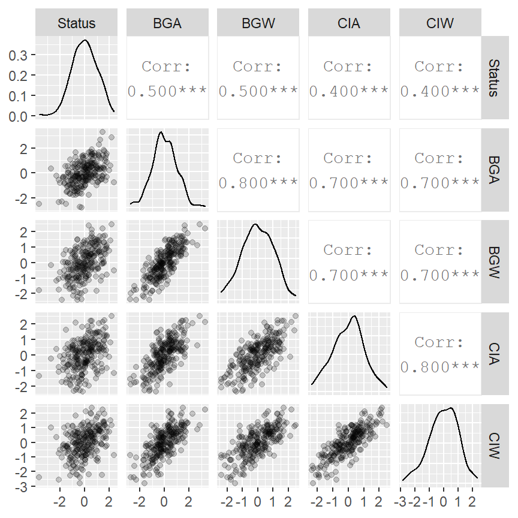

Case 4. High collinearity

```r
cmatCase4 <- c(1, .5, .5, .4, .4,
                 .5, 1, .8, .7, .7,
                 .5, .8, 1, .7, .7,
                 .4, .7, .7, 1, .8,
                 .4, .7, .7, .8, 1)
Case4.df <- rnorm_multi(240, 5, 0, 1,
  cmatCase4,
  varnames = c("Status", "BGA", "BGW", "CIA", "CIW"),
  empirical = TRUE)

ggpairs(Case4.df,
        lower = list(continuous = wrap(ggally_points,
                                       alpha = .2)))
```

Case 5 exhibits severe collinearity. *Within* domains, ability and willingness predictors *r* = 0.90. *Across* domains, benefits and costs predictors *r* = 0.80. These exceptionally strong associations most closely approximate the strong intercorrelations among DLB’s predictor variables.

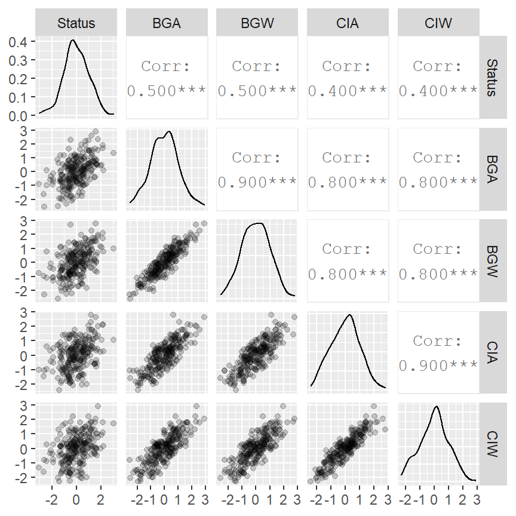

Case 5. Severe collinearity

```r
cmatCase5 <- c(1, .5, .5, .4, .4,
                 .5, 1, .9, .8, .8,
                 .5, .9, 1, .8, .8,
                 .4, .8, .8, 1, .9,
                 .4, .8, .8, .9, 1)
Case5.df <- rnorm_multi(240, 5, 0, 1,
  cmatCase5,
  varnames = c("Status", "BGA", "BGW", "CIA", "CIW"),
  empirical = TRUE)

ggpairs(Case5.df,
        lower = list(continuous = wrap(ggally_points,
                                       alpha = .2)))
```

Next, to compare the impact of these differing degrees of collinearity, we regress `Status` on all 4 predictors simultaneously—`BGA`, `BGW`, `CIA`, and `CIW`—in Bayesian models using each of the 5 simulated datasets. In all five cases, for which the true association is known, the expected standardized beta coefficient, $\beta$, that measures the association of `Status` with benefit-generation and cost-infliction is expected to be $\beta$ = 0.50 and 0.40, respectively. As in DLB, we used default noninformative priors for all model parameters.

Table 1 displays the model estimates for benefit-generation and cost-infliction ability and willingness. First, note the difference across cases in the $\beta$ parameter. For the $\beta$s on `BGA` and `BGW`, which have a true value of 0.50 (as accurately captured by Case 1 results), as collinearity increases the estimated coefficients *decrease*. In fact, under severe collinearity (Case 5), the coefficients become roughly half of its true value at $\beta$s = 0.29 - 0.30. For the $\beta$s on `CIA` and `CIW`, which have a true value of 0.40, the decrease in magnitude as collinearity increases is even more striking, as it even becomes *negative*, $\beta$ = -0.04, under severe collinearity (Case 5).

Second, consider the increased variance of the model estimates under collinearity. The standard errors of the $\beta$s increase in magnitude as collinearity increases from Case 1 to Case 5, first slowly and then more rapidly as collinearity becomes high or severe. Under severe collinearity, where *r*s among predictors = 0.80 - 0.90 (Case 5), the standard errors of the $\beta$s have a 4-5 fold increase compared to when collinearity is completely absent (Case 1). Along with the increase in these standard errors, of course, are widened confidence intervals (*CI*s) around each estimate as collinearity increases.

Note, this exercise decisively demonstrates that DLB’s data and analysis are not suitable for making the inferences that they in fact made regarding the relative and absolute effect sizes of the impacts of costs and benefits on status.

These adverse effects of collinearity on parameter estimates and their standard errors have been similarly observed in many datasets and across a range of disciplines (Cohen et al., 2013; Gordon, 1968; Hoffmann, 2010; Kleinbaum et al., 2013; Kutner et al., 2005; McElreath, 2020).

Table 1 | Data simulations show that model estimates are severely negatively biased and imprecisely estimated under high collinearity (Bayesian linear regression).

|  | Case.1 | Case.2 | Case.3 | Case.4 | Case.5 |
| --- | --- | --- | --- | --- | --- |
| BGA | 0.50 (0.44 – 0.56) (0.03) | 0.37 (0.29 – 0.45) (0.04) | 0.26 (0.11 – 0.39) (0.07) | 0.26 (0.07 – 0.46) (0.10) | 0.30 (0.03 – 0.56) (0.14) |
| BGW | 0.50 (0.45 – 0.55) (0.03) | 0.37 (0.29 – 0.46) (0.04) | 0.26 (0.12 – 0.39) (0.07) | 0.27 (0.07 – 0.46) (0.10) | 0.29 (0.03 – 0.56) (0.14) |
| CIA | 0.40 (0.35 – 0.45) (0.03) | 0.27 (0.19 – 0.36) (0.04) | 0.09 (-0.04 – 0.23) (0.07) | 0.02 (-0.18 – 0.22) (0.10) | -0.04 (-0.30 – 0.22) (0.13) |
| CIW | 0.40 (0.34 – 0.45) (0.03) | 0.27 (0.19 – 0.36) (0.04) | 0.09 (-0.05 – 0.23) (0.07) | 0.01 (-0.18 – 0.21) (0.10) | -0.04 (-0.30 – 0.22) (0.13) |
| Intercept | -0.00 (-0.05 – 0.05) (0.03) | 0.00 (-0.08 – 0.08) (0.04) | 0.00 (-0.10 – 0.10) (0.05) | 0.00 (-0.10 – 0.11) (0.06) | 0.00 (-0.11 – 0.11) (0.06) |
| Observations | 240 | 240 | 240 | 240 | 240 |
| R<sup>2</sup> Bayes | 0.819 | 0.587 | 0.331 | 0.281 | 0.268 |

Paralleling the results above derived from a Bayesian approach, we obtain qualitatively similar results with a frequentist approach using ordinary least squares regressions. As shown in Table 2 below, we again observe that as collinearity increases, the estimated $\beta$s decrease in magnitude (and the decline is especially sharp for `CIA` and `CIW`) and their *CI*s widen.

**Table 2 | Data simulations show that model estimates are severely negatively biased and imprecisely estimated under high collinearity (ordinary least squares regression).**

|  | Simulated Dataset |  |  |  |  |
| --- | --- | --- | --- | --- | --- |
|  | Case.1 | Case.2 | Case.3 | Case.4 | Case.5 |
| Benefit-Generation Ability (BGA) | 0.50*** | 0.37*** | 0.26*** | 0.27*** | 0.30** |
|  | (0.03) | (0.04) | (0.07) | (0.10) | (0.14) |
| Benefit-Generation Willingness (BGW) | 0.50*** | 0.37*** | 0.26*** | 0.27*** | 0.30** |
|  | (0.03) | (0.04) | (0.07) | (0.10) | (0.14) |
| Cost-Infliction Ability (CIA) | 0.40*** | 0.27*** | 0.09 | 0.02 | -0.04 |
|  | (0.03) | (0.04) | (0.07) | (0.10) | (0.14) |
| Cost-Infliction Willingness (CIW) | 0.40*** | 0.27*** | 0.09 | 0.02 | -0.04 |
|  | (0.03) | (0.04) | (0.07) | (0.10) | (0.14) |
| Intercept | -0.00 | 0.00 | -0.00 | -0.00 | 0.00 |
|  | (0.03) | (0.04) | (0.05) | (0.06) | (0.06) |
| Observations | 240 | 240 | 240 | 240 | 240 |
| R<sup>2</sup> | 0.82 | 0.59 | 0.33 | 0.28 | 0.26 |
| Adjusted R<sup>2</sup> | 0.82 | 0.58 | 0.32 | 0.27 | 0.25 |
| Residual Std. Error (df = 235) | 0.43 | 0.65 | 0.83 | 0.86 | 0.86 |
| F Statistic (df = 4; 235) | 267.64*** | 84.05*** | 28.70*** | 22.64*** | 21.16*** |
| *Note:* | p<0.1; p<0.05; p<0.01 |  |  |  |  |
|  | OLS, standard errors in parentheses |  |  |  |  |

Results of these simulations illustrate the adverse impact of collinearity on inferences made on the basis of DLB’s results. DLB’s analyses purportedly show large positive effects of `BGA` and `BGW` on status allocation, but weak or non-existent effects for `CIA` and `CIW`. These results and conclusions, however, ignore the severe collinearity among predictors (similar in degree to our Case 5). These predictors provide almost perfectly redundant information, particularly the ability and willingness predictors (`BGA` & `BGW`, `CIA` & `CIW`, where *r*s = 0.80 - 0.91). As we illustrate above, such high levels of collinearity have a serious adverse impact on the parameter estimates—underestimating the effects of the collinear variables (especially the cost-infliction predictors) and increasing their standard errors. This statistical problem thus obscures the identification of key independent predictors of `Status`, as any important predictors may be erroneously revealed to be unimportant in their models. DLB’s results are thus uninformative regarding how benefit-delivery and cost-infliction contribute to status allocation.

## S1.3 Partially correcting for collinearity in Durkee et al.’s models

Fully correcting for collinearity would entail reducing the correlation among predictors substantially to below *r* = 0.10. Other simulation studies reveal that even modest correlations among predictors in the range of *r* = 0.20 can produce changes in coefficient estimates and standard errors (Cohen et al., 2013; Vatcheva et al., 2016). Given the severe collinearity among all four predictors in DLB’s models (*r*s = 0.45 - 0.91), a full correction—which necessitates dropping all but one of DLB’s predictors—is untenable since this would make their central question unanswerable.

Note, however, that similar analyses conducted in other existing work (including our own; Cheng et al., 2010, 2013), which deploy measures of prestige and dominance that are uncorrelated or only weakly negatively correlated, are free of this collinearity problem. These uncorrelated or weakly correlated measures of the same concepts are thus better suited for investigations like the present one aimed at identifying the determinants of status.

Although a full correction of collinearity in DLB’s models is not possible, here we partially correct for it through a series of model re-specifications. These alternative analyses reveal that even a small partial correction produces different conclusions to those claimed by DLB.

Model re-specification, such as by combining collinear variables or dropping redundant variables, is one of the first lines of remedy for collinearity problems (Cohen et al., 2013; McElreath, 2020). It is particularly well suited for data (such as DLB’s) in which collinearity stems from overlapping conceptual content of the highly correlated variables (here, for example, a person seen as *able* to generate benefits for others is also regarded as more *willing* to provide those benefits). A range of other methods have been developed to address collinearity—from clustering or the use of latent methods to extract a subset of variables, to alternative modeling techniques such as ridge regressions—but these methods vary in effectiveness and each have unique limitations (see: Dormann et al., 2013; Kiers & Smilde, 2007).

As discussed above and shown in Figure 1, the collinearity problem is most severe among predictors `BGA` and `BGW` (*r* = 0.87 - 0.91), and between `CIA` and `CIW` (*r* = 0.80 - 0.84). As a first approach to reduce collinearity among these predictors, we combined each of these pairs of variables into a single aggregated index, labeled `BGcomposite` and `CIcomposite`. This approach is justified by (1) the strong empirical overlap among these variables, and (2) the lack of clear theoretically driven rationale for expecting a strong theoretical differentiation between *ability* and *willingness*. In fact, DLB and other researchers (Cheng et al., 2013; Henrich & Gil-White, 2001) premise their conclusions on benefit-delivery and cost-infliction broadly, without distinguishing between the empirically indistinguishable ability and willingness. To examine the effect of this re-specification, we use the same analytic approach as deployed by DLB but here include only these two composite indices as predictors.

Our results are displayed in Table 3, to the right of DLB’s original results from models that include all four collinear predictors (that is, columns ‘All.Predictors’), which we reproduce here using the authors’ analysis code (their findings are reported in their Fig. 3). Our model estimates now show that, for male targets, both `BGcomposite` and `CIcomposite` positively predict `Status` projections—in contrast to DLB’s finding of a weak or null effect of cost-infliction for men. For female targets, however, we find that while `BGcomposite` positively predicts `Status`, `CIcomposite` remains a null predictor.

Table 3 | Perceived status impact is unrelated to cost-infliction when all four collinear predictors are included, but is positively predicted by cost-infliction when benefits and costs composites are included as predictors instead.

|  | All.Predictors: Men | All.Predictors: Women | Composites: Men | Composites: Women |
| --- | --- | --- | --- | --- |
| Predictors | Estimates | Estimates | Estimates | Estimates |
| BGA | 0.38 (0.29 – 0.47) (0.05) | 0.61 (0.52 – 0.69) (0.04) |  |  |
| BGW | 0.43 (0.32 – 0.54) (0.05) | 0.28 (0.19 – 0.37) (0.04) |  |  |
| CIA | 0.11 (0.03 – 0.19) (0.04) | 0.06 (-0.04 – 0.15) (0.05) |  |  |
| CIW | 0.06 (-0.03 – 0.15) (0.05) | -0.01 (-0.07 – 0.06) (0.03) |  |  |
| BGcomposite |  |  | 0.78 (0.73 – 0.84) (0.03) | 0.86 (0.80 – 0.93) (0.03) |
| CIcomposite |  |  | 0.18 (0.11 – 0.24) (0.03) | 0.04 (-0.03 – 0.11) (0.03) |
| Intercept | -0.01 (-0.04 – 0.03) (0.02) | 0.00 (-0.04 – 0.04) (0.02) | -0.01 (-0.04 – 0.03) (0.02) | -0.00 (-0.04 – 0.04) (0.02) |
| N | 14 <sub>Country</sub> | 14 <sub>Country</sub> | 14 <sub>Country</sub> | 14 <sub>Country</sub> |
|  | 240 <sub>item_id</sub> | 240 <sub>item_id</sub> | 240 <sub>item_id</sub> | 240 <sub>item_id</sub> |
| Observations | 3069 | 3069 | 3069 | 3069 |
| Marginal R<sup>2</sup> / Conditional R<sup>2</sup> | 0.824 / 0.900 | 0.823 / 0.902 | 0.824 / 0.899 | 0.816 / 0.902 |

Why `CIcomposite` does not reliably predict `Status` in women targets is a puzzle worth considering. Recall our results above (and illustrated in Figure 1) revealing higher collinearity between benefit generation and cost-infliction in female targets relative to males (e.g., *r* between `BGA` and `CIA`= 0.81 for females vs. 0.45 for males). This raises the possibility that the two composite indices may still suffer from collinearity in female targets, compared to males. Confirming this expectation, the correlation between `BGcomposite` and `CIcomposite` is much stronger for female targets than male targets, and the VIFs in females (but not in males) exceed the 2.5 threshold:

Particularly strong correlations among benefits and costs composite predictors in women.

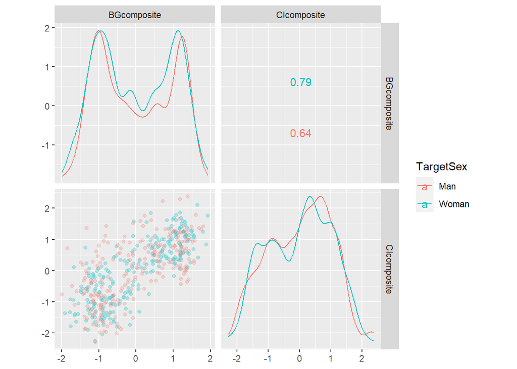

```r
library(car)

ols.composite.men <-
  lm(Status ~ BGcomposite + CIcomposite,
     data = agg_df %>% filter(TargetSex == "Man"))
vif(ols.composite.men)   # get vif in male targets
```

```
## BGcomposite CIcomposite
##    1.707661    1.707661
```

```r
ols.composite.women <-
  lm(Status ~ BGcomposite + CIcomposite,
     data = agg_df %>% filter(TargetSex == "Woman"))
vif(ols.composite.women) # get vif in female targets
```

```
## BGcomposite CIcomposite
##    2.647302    2.647302
```

Having identified this persisting collinearity issue in the composite indices among female targets leads us to a second re-specification approach, in which we included only one benefits and one costs predictors, rather than composites. Using this second approach, we found a positive significant effect of cost-infliction among women (as well as in men). In their respective models, `CIA` and `CIW` each reliably predict higher `Status` projections in both female and male targets.

Although the two predictors included in these models—`BGA` and `CIA` or `BGW` and `CIW`—are, on average, less strongly correlated with each other compared to `BGcomposite` and `CIcomposite`, their associations are nevertheless still too strong (*r*s = 0.45 - 0.81) to consider these models free of collinearity issues. Thus, while we consider our re-specifications to partially reduce collinearity, this issue remains pervasive in DLB’s original data and continues to severely limit any inferences from these data. As our simulations above suggest, even in these re-specified models where collinearity exists, the effects of cost-infliction are still likely to be severely underestimated.

Table 4 | Perceived status impact increases with cost-infliction for both male and female targets.

|  | Ability: Men | Ability: Women | Willingness: Men | Willingess: Women |
| --- | --- | --- | --- | --- |
| Predictors | Estimates | Estimates | Estimates | Estimates |
| BGA | 0.74 (0.69 – 0.79) (0.03) | 0.77 (0.71 – 0.85) (0.04) |  |  |
| CIA | 0.26 (0.21 – 0.32) (0.03) | 0.14 (0.07 – 0.21) (0.04) |  |  |
| BGW |  |  | 0.79 (0.72 – 0.87) (0.04) | 0.77 (0.70 – 0.84) (0.03) |
| CIW |  |  | 0.13 (0.05 – 0.21) (0.04) | 0.14 (0.07 – 0.20) (0.03) |
| Intercept | -0.00 (-0.05 – 0.04) (0.02) | -0.00 (-0.04 – 0.04) (0.02) | -0.00 (-0.05 – 0.04) (0.02) | -0.00 (-0.05 – 0.05) (0.03) |
| N | 14 <sub>Country</sub> | 14 <sub>Country</sub> | 14 <sub>Country</sub> | 14 <sub>Country</sub> |
|  | 240 <sub>item_id</sub> | 240 <sub>item_id</sub> | 240 <sub>item_id</sub> | 240 <sub>item_id</sub> |
| Observations | 3069 | 3069 | 3069 | 3069 |
| Marginal R<sup>2</sup> / Conditional R<sup>2</sup> | 0.800 / 0.898 | 0.808 / 0.901 | 0.799 / 0.899 | 0.737 / 0.902 |

Together, these simulation and re-analysis results reveal the sensitivity of DLB’s results to collinearity. Their misleading claims are heavily driven by collinearity among predictors. As our simulations above highlight, `CIA` and `CIW` are nearly perfectly redundant predictors. Although both have strong positive relations with `Status` projections, neither helps to explain this outcome *once you already know the impact of the other*. When we apply even a small correction for the problem of collinearity through model re-specification, DLB’s main conclusions are overturned and *both* benefits and costs emerge as reliable predictors of `Status`.

Nevertheless, one might be tempted to conclude from these re-analyses that even after partially correcting for collinearity in re-specified models, the effect of dominance is estimated to be much weaker than that of prestige (by a factor of 3-6). However, a crucial consideration (as noted above) is that even in our re-specifications, associations among predictors are only somewhat ameliorated and collinearity remains high (*r*s > 0.64 in composite models, > 0.45 in ability models, and > 0.61 in willingness models). Our simulations above indicate that at these levels of collinearity (Cases 4 and 5), the effect of dominance may still be *under*estimated by 4-40 times. Similar efforts by statisticians have led to similar conclusions (Vatcheva et al., 2016), revealing that even with *r* = 0.25 among predictors, significant multicollinearity effects may lead to unstable coefficient estimates. Given the severe collinearity in DLB’s data, then, the contribution of dominance to status projections in these partially corrected models is still seriously underestimated.

The problems of collinearity aside, we now turn to another issue that, in conjunction with collinearity, generates a second reason for the weaker observed effects of dominance: how social status is operationalized and measured.

# S2. Problems with operationalization and measurement of social status

In this section, we examine a second way in which the data provided by DLB results in biased conclusions: their problematic operationalization and measurement of status, which causes their methods to primarily capture prestige, a status based on freely conferred deference, and excludes status that can derive from dominance (Henrich & Gil-White, 2001). We present results from two studies we conducted to demonstrate the problematic nature of their measures, and discuss implications for their conclusions.

## S2.1 Measures of (projected) status are biased to primarily capture prestige

The central outcome variable in DLB’s study is participants’ beliefs about the status impact of various factors. Table 5 displays the prompts used by DLB to measure perceived status impact in the 14 countries sampled.

Table 5 | DLB’s prompts used to measure participants’ perceptions of status impact across sampling sites (English translations added here).

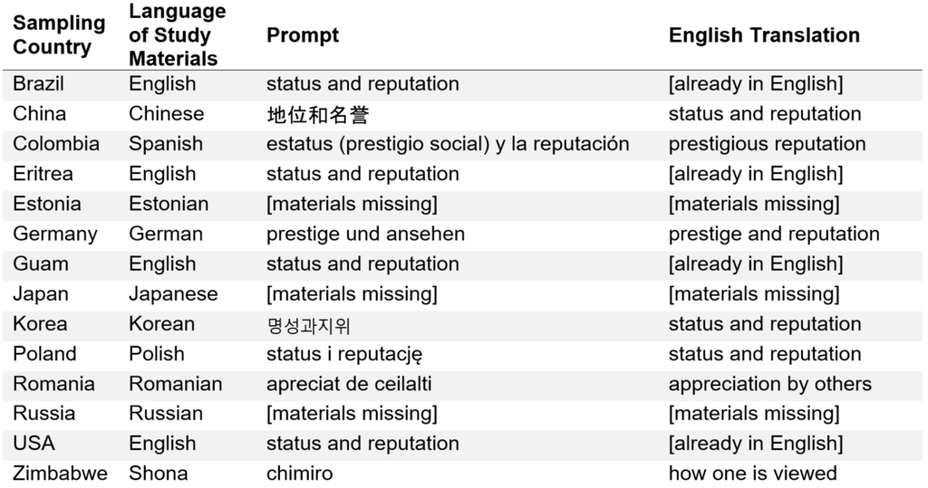

Inspection of these promots reveals that, at the majority of research sites, DLB used problematic prompts that operationalized status with terms that semantically cue mostly prestige. More specifically, in Brazil, China, Eritrea, Guam, Korea, Poland, and the USA, participants were asked to indicate how a set of traits, qualities, or behaviors increases or decreases the ‘status and reputation’ of its carrier or performer, which implies a positive reputation. Even more problematically, several other countries (Colombia, Germany) used the phrase ‘prestigious reputation’ or ‘prestige and reputation’. The most flawed prompt was in Romania, which used ‘appreciated by others’. Owing to the word choice of these prompts, which refer to status based on prestige (i.e., respect, positive reputation), participants were effectively indicating how each item enhances prestige-based status. It is therefore unsurprising that participants largely endorsed benefit-delivery (prestige) items, and not cost-infliction (dominance) items, as a key means of attaining this kind of status. Let’s consider, for example, the phrase ‘status and reputation’.

We thank Durkee et al., for responding to our request for clarification, sharing their materials, and to our notification of our intent to submit this commentary. Sites for which the authors indicated no longer having access to the study materials are denoted ‘materials missing’. For all non-English materials, We asked native speakers of those languages to provide English translations.

We took several steps to verify our interpretation that these prompts primarily capture prestige and not dominance. First, we consult the common usage of each word as reflected in dictionaries. For the two most frequently used promopts—‘status’ and ‘reputation’—the dictionary definitions are as follows:

Note that of the different flawed phrases used across sites, “status and reputation” appears the least problematic. Phrases ‘prestige and reputation’ and ‘appreciated by others’ are obviously even more biased toward capturing only prestige.

> *status 1* *: a position or rank in relation to others: relative rank in a hierarchy of prestige, especially: high prestige*

> *reputation 2* *: a place in public esteem or regard: good name*

Note that the synonym for ‘status’ is ‘prestige’, and that ‘reputation’ is synonymous with ‘esteem’ and ‘good name’, both of which imply a positive reputation. These definitions accord with our interpretation that the common-sense meaning of ‘status and reputation’ leans heavily towards capturing only prestige, a form of deference that is voluntarily conferred. We further confirm these observations with data below.

## S2.2 Evidence of substantial semantic overlap between Durkee et al.’s measure of status (‘status and reputation’) and prestige

We conducted a study of the semantic similarity among status-related words in English speakers. We presented 108 (50% women) English-speaking participants who reside in the U.S with a random subset of 60 status-word pairs. They were instructed: “Below is a pair of words or phrases. Please rate how similar they are to each other in meaning. A new word pair will be shown automatically after you select an answer”, and then viewed the word pair to be rated (e.g., Prestige vs. Authority). Each word pair was rated by 9-29 participants (*M*<sub>raters</sub> = 17.99), on a scale ranging from 1 (Not at all similar in meaning) to 7 (Extremely similar in meaning). Ratings for each word pair were aggregated across all participants in our analyses below. Figure 2 provides the full list of 27 status-related words and phrases used; these 27 words and phrases combine into 351 paired combinations.

These 27 status-related words and phrases were culled from existing theoretical and empirical work on social status (e.g., Anderson et al., 2020, 2001; Anderson & Kilduff, 2009; Cheng et al., 2010, 2013; Garfield & Hagen, 2020; Henrich & Gil-White, 2001; Lukaszewski et al., 2016; Maner, 2017; Maner & Case, 2016; Maner & Mead, 2010; Von Rueden et al., 2008).

Using the resulting average similarity ratings between each pair of words, we assessed the extent to which the words form distinct groups (clusters) of semantic meaning. As shown in Figure 2, hierarchical cluster analysis of these similarity ratings suggest 3 major clusters, which can roughly be described as: (1) prestige (benefit-delivery), (2) influence (general status, ambiguous in form), and (3) dominance (cost-infliction). More specifically, the first cluster (colored in purple) is comprised of prestige words (Achievement, Success, Recognition, Expertise, Skills, Competence, Prestige, Status, Reputation, Admiration, Respect, Reverence, Attended to). The second cluster (colored in orange) is comprised largely of general influence words and phrases (Authority, In charge, Control, Dominance, Being the leader, Decision-making impact, Influence). Finally, the third cluster (colored in green) is comprised of the remaining dominance words (Force, Coercion, Fear, Bully, Intimidation, Threat, Aggression). Importantly, both ‘Status’ and ‘Reputation’ clustered with the other prestige words in the first cluster, and are most distant (and by implication, dissimilar) from the dominance words (the third cluster). This pattern confirms our interpretation that DLB’s measure of status captures non-coercive, prestige-based status. Participants’ judgments of the traits and behaviors that impact this form of status are consequently biased toward those most relevant to benefit-delivery (prestige), and away from those relevant to cost-infliction (dominance).

Figure 2 | Hierarchical cluster analysis of status words based on participants’ ratings of semantic similarity. Clusters were agglomerated using Ward’s algorithm. ‘Status’ and ‘Reputation’ are capitalized here only for emphasis, and in our study materials were presented in lower case and no differently from other status words.

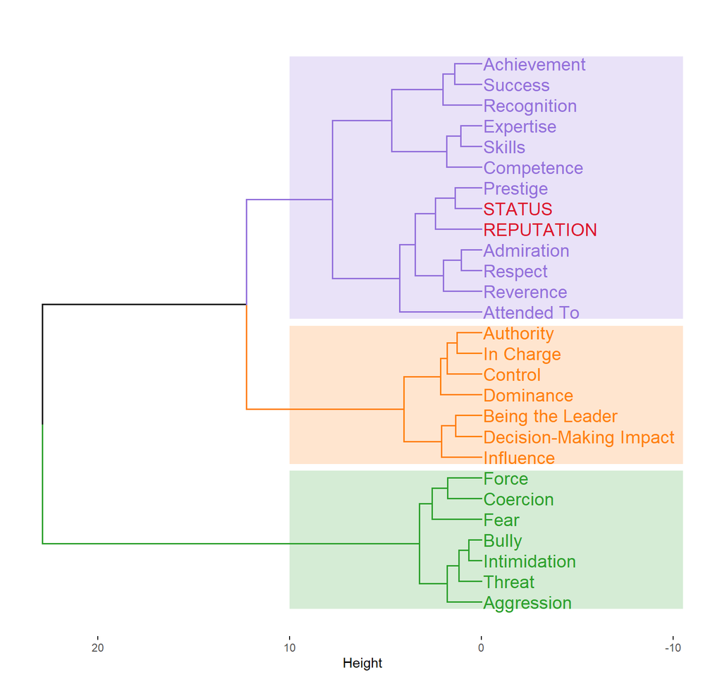

Notice how, as shown on the right of the figure, both ‘Status’ and ‘Reputation’ are rated as more similar to words in the prestige cluster than to words in the dominance or influence cluster, and the same is true of ‘Reputation’. This confirms again that, in common parlance, the English words ‘Status’ and ‘Reputation’ suggest prestige-based deference and have little coercive connotation. Even more importantly, these words do not strongly capture influence more generally. This is in contrast to terms such as ‘Influence’ and ‘Decision-Making Impact’, which, as shown on the left side of the figure, have the strongest influence indications, and overlap much more weakly with prestige words, compared to ‘Status’ and ‘Reputation’. These data thus highlight the serious problem in DLB’s measure of perceived status impact: it fails to impartially capture coercive forms of influence, or the broader concept that should underpin any definition of status: influence.

Figure 3 | Rated semantic similarity of ‘Status’, ‘Reputation’, Influence’, and ‘Decision-Making Impact’ with other status words. Filled circles indicate the mean similarity rating of the word given on the x-axis with the *average* word in the prestige, influence, or dominance cluster. Error bars indicate the 95% confidence interval.

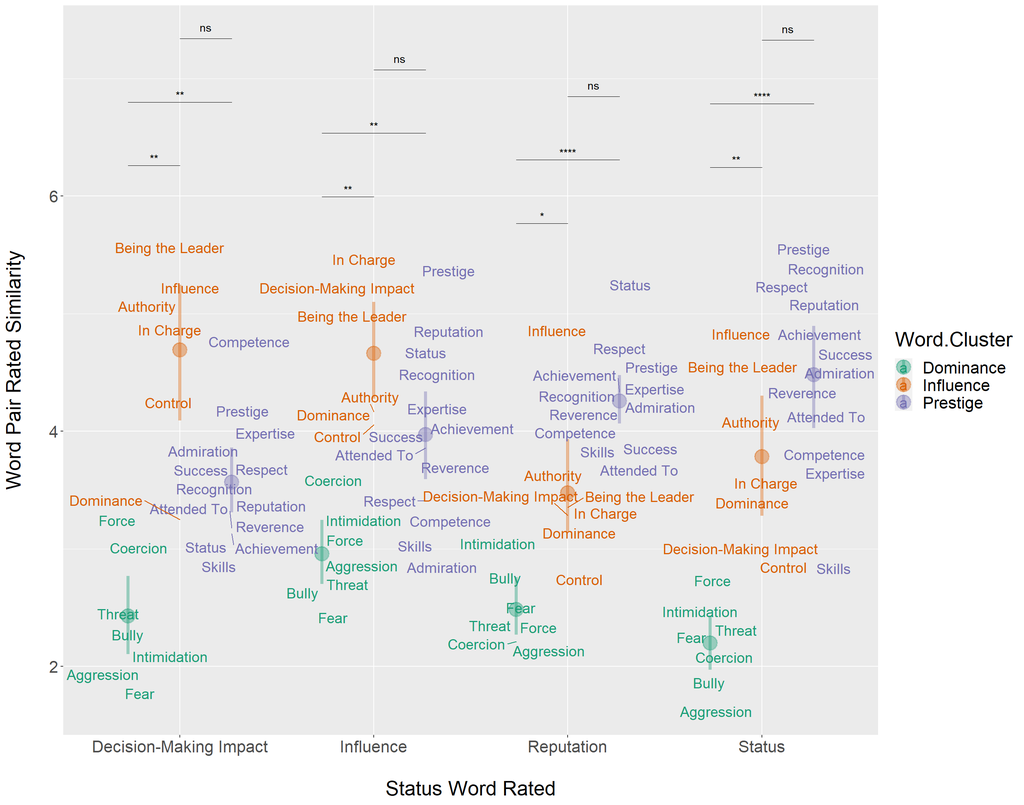

## S2.3 How other existing work operationalizes status

How do other studies operationalize ‘status’? In the theoretical work that provides the foundations for the evolutionary model that DLB claims to test, Henrich & Gil-White (2001) argue for a conceptual emphasis on patterns of deference:

> *“Status can be viewed as either a hierarchy of rewards or as a hierarchy of displays–or both simultaneously… high status entails greater access to desirable things… higher status individuals–identified by the flow of benefits–are typically the receivers, rather than the givers, of *deference* displays”* (p. 166).

This theoretical emphasis highlights that a core prediction emerging from this theory is that prestige and dominance both shape the within-group asymmetries of *deference* and *privilege*.

In accordance with this emphasis, much of the empirical work guided by this theoretical framework (e.g., Cheng et al., 2013; Anderson et al., 2020; Brand & Mesoudi, 2019; Maner & Mead, 2010) has since sought to test how prestige and dominance contribute to differential influence, a prime index of deference and privilege in human dyadic interactions and social groups.

## S2.4 Evidence that any results concerning the importance of dominance are sensitive to how status is measured

Another *n* = 52 were excluded due to failing an attention check (complete sample size: *N* = 882).

Data for the degree to which each trait, practice, or behavior is seen to deliver benefits or inflict costs (i.e., the affordance variables—`BGA`, `BGW`, `CIA`, and `CIW`) were taken directly from the original data made available by DLB. As described in Sec 1, to reduce collinearity, we computed `CIcomposite` and `BGcomposite` by aggregating across `CIA` and `CIW`, and `BGA` and `BGW`, respectively.

Figure 4 | Correlation matrix showing pairwise associations between benefit-generation ability (BGA) and willingness (BGW), and cost-infliction ability (CIA) and willingness (CIW), the composite of benefits (BGcomposite) and costs (CIcomposite), and status impact ratings as evaluated on 10 different status prompts.

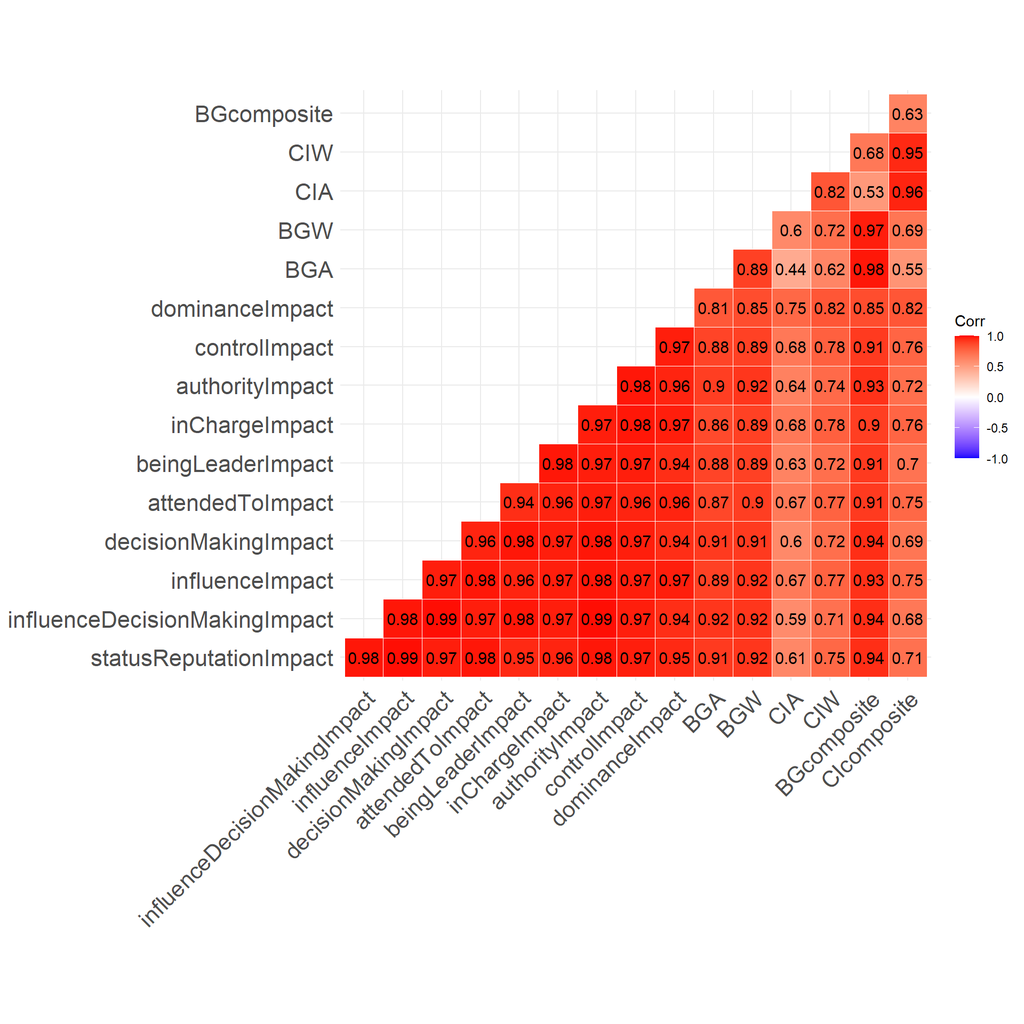

Second, we examined the importance of cost-infliction independently of benefit-delivery, per DLB’s analyses. To do so, we built Bayesian models by adapting the original code used by the authors, while entering `BGcomposite` and `CIcomposite` as predictors to partially (though not fully) attenuate collinearity (in the place of DLB’s predictors `BGA`, `BGW`, `CIA`, and `CIW`, which, as shown in Sec 1 above, generate severe collinearity). In each of the 10 models constructed, a different status prompt (of the 10) was modeled as the outcome. However, note that, as shown in Figure 4 above (and detailed in Sec 1), even with these composite variables, serious collinearity concerns persisted, given their substantial overlap (*r* = 0.6). Nonetheless, using the 9 new status terms as outcome variables, we obtain notably different results from DLB. As shown below in Figure 5, across *all* 10 models, `CIcomposite` has a positive, non-zero effect on projected status impact. Furthermore, ‘status and reputation’ yield coefficients for benefit-delivery and cost-infliction that are at the extreme ends, in terms of placing the largest effect on benefits over costs. A similar pattern is found for ‘influence and decision-making impact’. For some terms—‘dominance’, ‘being in charge’, ‘control’, ‘being attended to’, and ‘influence’—benefits and costs have relatively more equal weights, though the effect of benefits remains more sizable than that on costs. Importantly, however, for all terms, the coefficients of cost-infliction are at least 2-3 times larger than those that emerged in DLB’s original results, illustrating the large impact that the choice of status prompt can have on results.

Resolving collinearity entirely would require abandoning all of DLB’s data and collecting new data in which dominance and prestige are assessed using measures that more clearly differentiate between these processes. See Sec 3 for a summary of such existing work.

We surmise that the collinearity present in DLB’s measures of benefits and costs (see Sec 1), in conjunction with the assessment of *beliefs* about status rather than *actual* status relations (see Sec 3 below), leads to a substantial under-estimation of the coefficients. As shown in existing studies that assess actual status outcomes and that use measures absent of collinearity concerns, prestige and dominance can have equal weights on status (see summary of prior evidence in Sec 3).

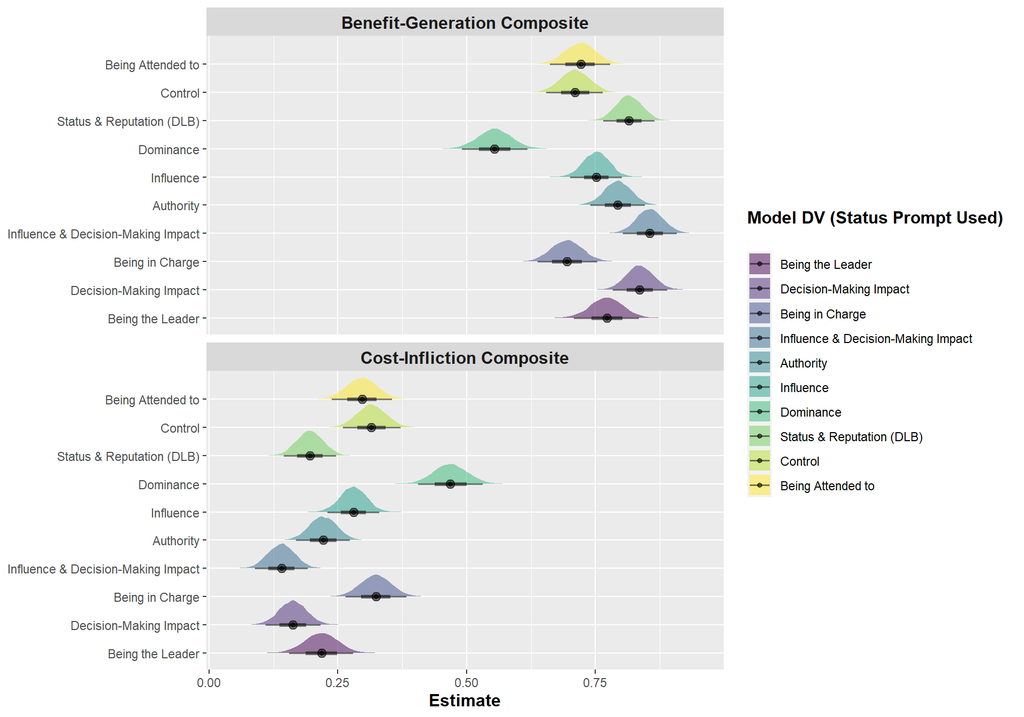

Figure 5 | Standardized estimates from Bayesian models predicting status impact (measured using a range of status prompts) from benefit-delivery and cost-infliction. 95% confidence intervals are shown.

When we repeat these analyses under a frequentist approach using ordinary least squares regressions, the same results are obtained. Cost-infliction (as well as benefit-delivery) consistently predicts greater status acquisition across all measures of status than that observed by DLB. However, considerable variation exists in the magnitude of the effect depending on the specific status term used. The term ‘status and reputation’ produces one of the weakest effects of cost-infliction and the strongest effects of benefit delivery.

In our study, projected status impact was measured only among participants from the USA. We are therefore unable to address how these different status prompts perform across societies. Note, however, that in DLB’s findings there is no indication that the USA is an outlier that deviates substantially from other nations and states sampled in terms of the relative importance of benefit-delivery or cost-infliction (see DLB, Fig. 3).

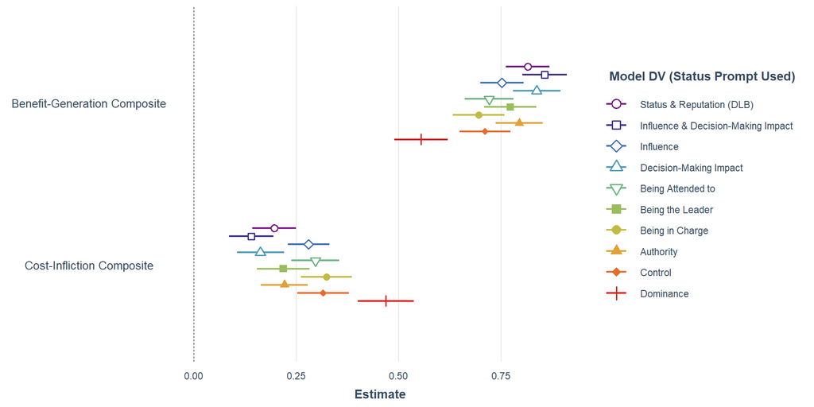

Figure 6 | Standardized estimates from ordinary least squares models predicting status impact (measured using a range of status prompts) from benefit-delivery and cost-infliction. 95% confidence intervals are shown.

To summarize, while DLB maintain that their goal is to explore the psychological foundations of “hierarchical structure” and how people come to occupy a certain “rank within a hierarchy” (Durkee et al., 2020, p. 21235), close inspection of their study materials, along with evidence from two new studies presented here, reveals serious problems with their operationalization of status; these problems severely undermine their goal. The prompt ‘status and reputation’, which was used as their key measure of status across most sites, represents a serious methodological flaw, as most people interpret this phrase as implying prestige–a form of status largely synonymous with benefit-generation. DLB’s results therefore *only* demonstrate how traits, behaviors, and practices are believed to increase one’s perceived *prestige standing*—but crucially, not one’s overall status or influence. When the study is re-conducted (as we have done here) using less prestige-centric status prompts that span the range defined by theories of social status, cost-infliction consistently predicts increased projected status—a result opposite to that claimed by DLB. Moreover, the measured importance of cost-infliction is highly sensitive to how status is cued in the study instructions. In sum, it is problematic to purport to test a theory of status as derived from both prestige and dominance but only use methods that semantically capture prestige, then claim to find no impact of dominance.

In contrast to the approach taken by DLB, other work on human status has been careful to avoid these methodological flaws. In these prior studies, researchers have assessed status as potentially resulting from both coercive and freely conferred deference, while using prestige and dominance predictors that do not suffer from collinearity. In addition, in these prior studies, status has been assessed not merely on the basis of surveying people’s subjective *beliefs* (as was done in DLB), but instead by directly measuring how status (i.e., social influence, leadership, informal power) is *actually* allocated. We turn next to this issue and provide an overview of the large body of existing findings demonstrating the importance of dominance.

# S3. Results hinges on the flawed assumption that beliefs capture reality

A final major concern we raise here is DLB’S exclusive methodological reliance on people’s subjective reports about what warrants status, in a study that purports to determine how status is allocated in real life. This is a rather untenable assumption given that subjective reports of social dynamics have long been discredited as accurate portrayal or reliable evidence for real behavior or actions (Baumeister et al., 2007; Nisbett & Wilson, 1977 ), making this a problematic approach. In this case, the problem is compounded by the fact that people hold varying beliefs about how status is acquired (Ten Brinke & Keltner, in press). Perhaps most importantly, other studies that have examined actual status relations within groups, in real life contexts, consistently find that both prestige and dominance contribute to status attainment, and can have a similarly large impact. Below, we briefly summarize the findings from these prior studies examining actual status asymmetries (rather than beliefs about asymmetries).

## S3.1 Why status allocation cannot be directly inferred from people’s subjective beliefs

DLB’s results hinge on the flawed assumption that surveying what people believe to determine status can inform us about how status asymmetries actually form in real life. Yet, introspective subjective reports have long been discredited as accurate portrayals of reality (Baumeister et al., 2007; Nisbett & Wilson, 1977; West & Brown, 1975; Wilson, 2004; Wilson & Gilbert, 2003). At the very least, any inferences about the foundations of status made on the basis of DLB’s data would require evidence that subjective reports can track reality.

## S3.2 Existing evidence that dominance contributes to status

Studies that *have* examined actual status relations among real people, in the lab and naturalistic settings, consistently find that both prestige and dominance contribute to status, and can have a similarly large impact across a broad range of contexts and groups:

1. In Cheng et al. (2013), we tested in small ‘minimal’ laboratory groups whether prestige and dominance (each measured using reliable 8-item peer-rating scales) each result in greater deference, measured as (1) demonstrated behavioral impact over group decision-making, (2) amount of visual attention received (assessed by eye-tracking), and (3) group member ratings of who “led the task”, “was paid attention”, and “had high status”.
2. In subsequent work, these same measures were used to evaluate group members’ relative influence in the field among sports clubs, volunteer groups, businesses, bands, and chess clubs (Brand & Mesoudi, 2019), as well as collaborative student project teams (Redhead et al., 2019).
3. In Anderson et al. (2020)’s study of status and power in the workplace, status was measured using self- and coworker-reports on items that indicate an individual’s “influence over important decisions”, “influence in the everyday activities of the organization”, and ability to “get my [his/her] way” and “get others to listen to what I [he/she] say(s)”.

In these prior studies, dominance and prestige are found to have similarly large effects on influence (Brand & Mesoudi, 2019; Cheng et al., 2013; Garfield & Hagen, 2020). This is a striking departure from the substantially weaker effect of dominance observed by DLB—the only study in this larger body of work that measured status on the basis of people’s beliefs *and* that stands out as an idiosyncratic finding.

By confirming the status-enhancing effects of prestige and dominance, these field studies contradict DLB’s claim that “most evidence supporting the dual-pathway account, for example, is derived from laboratory-based interactions among previously unacquainted temporary groups, which may not function in the same way as real-world human groups” (p. 21236). For additional evidence from real-world social relations and groups, see Garfield & Hagen (2020) and Von Rueden et al. (2008).

Importantly, in light of the status terminology issue discussed above (see Sec 2), in *none* of these studies was status measured exclusively using ratings on single items such as ‘status’ or ‘reputation’ (or their combination). When ‘status’ is referenced in scale instruments, it is always complemented by efforts to additionally assess who has influence over the behavior of others, either via other scale items, observationally, or behaviorally. This methodological approach is sound, because, as our semantic similarity study reported above demonstrates, ‘status’ and ‘reputation’ imply prestige, specifically Thus an exclusive reliance on these terms would fail to generate data amenable to testing for possible effects of dominance-based deference.

One might wonder whether dominance is universally present and important across populations. After all, the people sampled in these studies described above are primarily from Western, Educated, Industrialized, Rich and Democratic (WEIRD) societies (Henrich et al., 2010), whereas DLB sampled across a number of nations and states, and this different might be assumed to explain the disparate findings. However, emerging evidence from small-scale foragers and horticulturalists confirm the importance of dominance-based status in these diverse populations. For example, in Von Rueden et al. (2014)‘s study of Tsimane’ forager-horticulturalists of Bolivia, physically dominant men are more likely to rise to and maintain leadership positions and exercise community-wide influence (also see Von Rueden et al. (2008) for similar findings). In Garfield & Hagen (2020)’s study on the traits and attributes of elected officials in Chabu, a small-scale society with a long history of egalitarianism, men who intimidate and are feared—a prime index of dominance—were over-represented in leadership positions. Thus, even within the most egalitarian societies, dominants appear able to dominate and gain deference despite strong cultural emphases on equality and respect for individual autonomy. Although more work is needed, the existing evidence of dominance- and prestige-based political leadership in small, kin-based societies with highly egalitarian social norms tentatively suggests the universality of these two avenues to status.

These findings confirming the importance of dominance-based status in diverse societies go unmentioned in DLB.

## S3.3 Misrepresentation of this body of prior evidence and theory

It is worth noting here that DLB’s investigation and their critique of the existing evidence (some of which summarized above) is premised on the idea that “it is both theoretically and empirically unclear whether the contribution of dominance to status is independent of valued competencies” (p. 21236). This interpretation suffers from a misinterpretation of the existing evidence. In all of these studies, the observed effects of dominance on influence are consistently obtained independently of the effects of prestige, as their effects on influence is always modeled by entering both as predictors simultaneously.

For examples of existing work demonstrating that the influence that accrues to dominant individuals is independent of any prestige-based deference, consult: Anderson et al. (2020), Brand & Mesoudi (2019), Cheng et al. (2013), Garfield & Hagen (2020), and Von Rueden et al. (2008).

On a theoretical front, DLB mispresents the dominance-prestige model that they criticize. Specifically, they sugggest that the original theory (Henrich & Gil-White, 2001) proposes that prestige and dominance *must* be orthogonal and individuals *cannot* simultaneously possess *both* prestige- and dominance-based status. For example, in emphasizing the (false) importance of orthogonality, the authors maintain that “in studies examining status in more ecologically valid groups, dominance and prestige are not consistently independent” (p. 21236). Elsewhere, they identify as a novel insight of their studies “our finding [is] that cost infliction is not orthogonal to benefit generation” (p. 21238). DLB’s critique is premised on the idea that, for dominance and prestige to be independent pathways to status, they must not covary. But this is a false assumption as neither the theory nor empirical models require prestige and dominance to be completely independent, only that they *can* independently give rise to asymmetries in deference. Their orthogonality has never a necessary condition, and in fact, in the original theoretical formulation of the prestige-dominance model, Henrich & Gil-White (2001) explain the theoretical basis for why the two pathways may at times covary:

> *“Although one may find prestige and dominance status in the same individual, the fact remains that qualitatively different stimuli elicit prototypical prestige and dominance responses. To lose sight of this distinction is to obscure our argument. Modern societies have complex, institutional hierarchies, so individuals often enjoy both dominance and prestige status. Presidents and school teachers, for example, have real control over rewards and punishments on the one hand, but may also be perceived as doing a good job, on the other. What justifies our distinction is not that individuals must always have only one or the other form of status, but that it is *possible* for humans to have only one or the other because the prototypical stimuli and the underlying psychologies are fundamentally different…”* (p.171)

Elsewhere (Cheng et al., 2013), we have further highlighted how *both* status processes may operate within the same individual, resulting in a non-zero correlation:

> *“Importantly, both Dominance and Prestige are best conceptualized as cognitive and behavioral strategies (i.e., suites of subjective feelings, cognitions, motivations, and behavioral patterns that together produce certain outcomes) deployed in certain situations, and can be used (with more or less success) by any individual within a group. They are not types of individuals, or even, necessarily, traits within individuals. Instead, we assume that all situated dyadic relationships contain differential degrees of both Dominance and Prestige, such that each person is simultaneously Dominant and Prestigious to some extent, to some other individual. Thus, it is possible that a high degree of Dominance and a high degree of Prestige may be found within the same individual, and may depend on who is doing the judging. For example, by controlling students’ access to rewards and punishments, school teachers may exert Dominance in their relationships with some students, but simultaneously enjoy Prestige with others, if they are respected and deferred to for their competence and wisdom.”* (p. 106)

In short, DLB’s decision to study the determinants of status asymmetries by surveying individuals’ subjective opinions about what they consider status-worthy is a sharp divergence from the prevailing methodological approach of assessing actual status relations in both the lab and field. Importantly, these other studies generate opposite conclusions to those of DLB, and reveal strong and consistent evidence of the importance of dominance. This methodological shortcoming, coupled with measuring status using prompts that are biased to cue prestige and non-coercive forms of status, seriously undermine DLB’s findings and may explain why they diverge from the conclusions that emerge from other work. Importantly, DLB’S results are the exception rather than the norm; other studies offer consistent evidence that dominance, along with prestige, is a central foundation of status.

# Conclusion

**A large body of existing work has tested hypotheses regarding the psychological foundations of human social status on the basis of prestige and dominance (Henrich & Gil-White, 2001). Support for predictions from the Dominance-Prestige account have emerged in studies that utilize behavioral or observational measures of actual status outcomes among real groups or communities of people (Anderson et al., 2020; Brand & Mesoudi, 2019; Cheng et al., 2013), and even among non-WEIRD forager societies (Garfield & Hagen, 2020; Von Rueden et al., 2008). DLB’s cross-cultural investigation of this hypothesis in 14 countries is laudable. However, their statistical issues, problematic operationalization of status, collinearity-generating measures of benefits and costs, and the reliance on self-reported beliefs undermine their central conclusion that prestige is the primary or sole foundation of human status. These statistical and methodological flaws render their data unable to address the questions they seek to answer. In other available evidence free from these limitations, a different conclusion emerge: prestige and dominance jointly form the foundations of human status.**

# References

Anderson, C., John, O. P., Keltner, D., & Kring, A. M. (2001). Who attains social status? Effects of personality and physical attractiveness in social groups. *Journal of Personality and Social Psychology*, *81*(1), 116–132.

Anderson, C., & Kilduff, G. J. (2009). The pursuit of status in social groups. *Current Directions in Psychological Science*, *18*(5), 295–298.

Anderson, C., Sharps, D. L., Soto, C. J., & John, O. P. (2020). People with disagreeable personalities (selfish, combative, and manipulative) do not have an advantage in pursuing power at work. *Proceedings of the National Academy of Sciences*, *117*(37), 22780–22786.

Baumeister, R. F., Vohs, K. D., & Funder, D. C. (2007). Psychology as the science of self-reports and finger movements: Whatever happened to actual behavior? *Perspectives on Psychological Science*, *2*(4), 396–403.

Berry, W. D., Feldman, S., & Stanley Feldman, D. (1985). *Multiple regression in practice*. Sage.

Brand, C. O., & Mesoudi, A. (2019). Prestige and dominance-based hierarchies exist in naturally occurring human groups, but are unrelated to task-specific knowledge. *Royal Society Open Science*, *6*(5), 181621.

Charafeddine, R., Mercier, H., Clément, F., Kaufmann, L., Reboul, A., Henst, V. der, & others. (2016). Children’s allocation of resources in social dominance situations. *Developmental Psychology*, *52*(11), 1843–1857.

Cheng, J. T., Tracy, J. L., Foulsham, T., Kingstone, A., & Henrich, J. (2013). Two ways to the top: Evidence that dominance and prestige are distinct yet viable avenues to social rank and influence. *Journal of Personality and Social Psychology*, *104*(1), 103–125.

Cheng, J. T., Tracy, J. L., & Henrich, J. (2010). Pride, personality, and the evolutionary foundations of human social status. *Evolution and Human Behavior*, *31*(5), 334–347.

Cohen, J., Cohen, P., West, S. G., & Aiken, L. S. (2013). *Applied multiple regression/correlation analysis for the behavioral sciences*. Routledge.

Dormann, C. F., Elith, J., Bacher, S., Buchmann, C., Carl, G., Carré, G., Marquéz, J. R. G., Gruber, B., Lafourcade, B., Leitao, P. J., & others. (2013). Collinearity: A review of methods to deal with it and a simulation study evaluating their performance. *Ecography*, *36*(1), 27–46.

Durkee, P. K., Lukaszewski, A. W., & Buss, D. M. (2020). Psychological foundations of human status allocation. *Proceedings of the National Academy of Sciences*, *117*(35), 21235–21241.

Garfield, Z. H., & Hagen, E. H. (2020). Investigating evolutionary models of leadership among recently settled ethiopian hunter-gatherers. *The Leadership Quarterly*, *31*(2), 101290.

Gordon, R. A. (1968). Issues in multiple regression. *American Journal of Sociology*, *73*(5), 592–616.

Grueneisen, S., & Tomasello, M. (2017). Children coordinate in a recurrent social dilemma by taking turns and along dominance asymmetries. *Developmental Psychology*, *53*(2), 265–273.

Henrich, J., & Gil-White, F. J. (2001). The evolution of prestige: Freely conferred deference as a mechanism for enhancing the benefits of cultural transmission. *Evolution and Human Behavior*, *22*(3), 165–196.

Henrich, J., Heine, S. J., & Norenzayan, A. (2010). The weirdest people in the world? *Behavioral and Brain Sciences*, *33*(2-3), 61–83.

Hoffmann, J. P. (2010). Linear regression analysis: Applications and assumptions. *Brigham Young University, Provo*, 1–285.

Johnston, R., Jones, K., & Manley, D. (2018). Confounding and collinearity in regression analysis: a cautionary tale and an alternative procedure, illustrated by studies of British voting behaviour. *Quality & Quantity*, *52*(4), 1957–1976.

Kiers, H. A., & Smilde, A. K. (2007). A comparison of various methods for multivariate regression with highly collinear variables. *Statistical Methods and Applications*, *16*(2), 193–228.

Kleinbaum, D. G., Kupper, L. L., Nizam, A., & Rosenberg, E. S. (2013). *Applied regression analysis and other multivariable methods*. Nelson Education.

Kutner, M. H., Nachtsheim, C. J., Neter, J., Li, W., & others. (2005). *Applied linear statistical models* (Vol. 5). McGraw-Hill Irwin New York.

Lukaszewski, A. W., Simmons, Z. L., Anderson, C., & Roney, J. R. (2016). The role of physical formidability in human social status allocation. *Journal of Personality and Social Psychology*, *110*(3), 385–406.

Maner, J. K. (2017). Dominance and prestige: A tale of two hierarchies. *Current Directions in Psychological Science*, *26*(6), 526–531.

Maner, J. K., & Case, C. R. (2016). Dominance and prestige: Dual strategies for navigating social hierarchies. In *Advances in experimental social psychology* (Vol. 54, pp. 129–180). Elsevier.

Maner, J. K., & Mead, N. L. (2010). The essential tension between leadership and power: When leaders sacrifice group goals for the sake of self-interest. *Journal of Personality and Social Psychology*, *99*(3), 482–497.

Margoni, F., Baillargeon, R., & Surian, L. (2018). Infants distinguish between leaders and bullies. *Proceedings of the National Academy of Sciences*, *115*(38), E8835–E8843.

McElreath, R. (2020). *Statistical rethinking: A Bayesian course with examples in R and Stan*. CRC press.

Nisbett, R. E., & Wilson, T. D. (1977). Telling more than we can know: Verbal reports on mental processes. *Psychological Review*, *84*(3), 231–259.

Redhead, D. J., Cheng, J. T., Driver, C., Foulsham, T., & O’Gorman, R. (2019). On the dynamics of social hierarchy: A longitudinal investigation of the rise and fall of prestige, dominance, and social rank in naturalistic task groups. *Evolution and Human Behavior*, *40*(2), 222–234.

Ten Brinke, L., & Keltner, D. (in press). Theories of power: Perceived strategies for gaining and maintaining power. *Journal of Personality and Social Psychology*.

Thomsen, L., Frankenhuis, W. E., Ingold-Smith, M., & Carey, S. (2011). Big and mighty: Preverbal infants mentally represent social dominance. *Science*, *331*(6016), 477–480.

Vatcheva, K. P., Lee, M., McCormick, J. B., & Rahbar, M. H. (2016). Multicollinearity in regression analyses conducted in epidemiologic studies. *Epidemiology (Sunnyvale, Calif.)*, *6*(2), 227.

Von Rueden, C., Gurven, M., & Kaplan, H. (2008). The multiple dimensions of male social status in an Amazonian society. *Evolution and Human Behavior*, *29*(6), 402–415.

Von Rueden, C., Gurven, M., Kaplan, H., & Stieglitz, J. (2014). Leadership in an egalitarian society. *Human Nature*, *25*(4), 538–566.

West, S. G., & Brown, T. J. (1975). Physical attractiveness, the severity of the emergency and helping: A field experiment and interpersonal simulation. *Journal of Experimental Social Psychology*, *11*(6), 531–538.

Wilson, T. D. (2004). *Strangers to ourselves*. Harvard University Press.

Wilson, T. D., & Gilbert, D. T. (2003). Affective forecasting. *Advances in Experimental Social Psychology*, *35*, 345–411.